# R Notebook

| X | genhlth | exerany | hlthplan | smoke100 | height | weight | wtdesire | age | gender |
| --- | --- | --- | --- | --- | --- | --- | --- | --- | --- |
| 1 | good | 0 | 1 | 0 | 70 | 175 | 175 | 77 | m |
| 2 | good | 0 | 1 | 1 | 64 | 125 | 115 | 33 | f |
| 3 | good | 1 | 1 | 1 | 60 | 105 | 105 | 49 | f |
| 4 | good | 1 | 1 | 0 | 66 | 132 | 124 | 42 | f |
| 5 | very good | 0 | 1 | 0 | 61 | 150 | 130 | 55 | f |
| 6 | very good | 1 | 1 | 0 | 64 | 114 | 114 | 55 | f |
| 7 | very good | 1 | 1 | 0 | 71 | 194 | 185 | 31 | m |
| 8 | very good | 0 | 1 | 0 | 67 | 170 | 160 | 45 | m |
| 9 | good | 0 | 1 | 1 | 65 | 150 | 130 | 27 | f |
| 10 | good | 1 | 1 | 0 | 70 | 180 | 170 | 44 | m |

[output cut: 990 more lines]

# Exercise 1: Prepare the data

## Read the data from file cdc.csv. Review the data types. For categorical binary variables, change 0-1 to “no”-“yes”.

## Split the data set into data for males and data for females.

|  | X | genhlth | exerany | hlthplan | smoke100 | height | weight | wtdesire | age | gender |
| --- | --- | --- | --- | --- | --- | --- | --- | --- | --- | --- |
| 1 | 1 | good | 0 | 1 | no | 70 | 175 | 175 | 77 | m |
| 2 | 2 | good | 0 | 1 | yes | 64 | 125 | 115 | 33 | f |
| 3 | 3 | good | 1 | 1 | yes | 60 | 105 | 105 | 49 | f |
| 4 | 4 | good | 1 | 1 | no | 66 | 132 | 124 | 42 | f |
| 5 | 5 | very good | 0 | 1 | no | 61 | 150 | 130 | 55 | f |
| 6 | 6 | very good | 1 | 1 | no | 64 | 114 | 114 | 55 | f |

```r
males <- data[data$gender == 'm',]
```

|  | X | genhlth | exerany | hlthplan | smoke100 | height | weight | wtdesire | age | gender |
| --- | --- | --- | --- | --- | --- | --- | --- | --- | --- | --- |
| 1 | 1 | good | 0 | 1 | no | 70 | 175 | 175 | 77 | m |
| 7 | 7 | very good | 1 | 1 | no | 71 | 194 | 185 | 31 | m |
| 8 | 8 | very good | 0 | 1 | no | 67 | 170 | 160 | 45 | m |
| 10 | 10 | good | 1 | 1 | no | 70 | 180 | 170 | 44 | m |
| 11 | 11 | excellent | 1 | 1 | yes | 69 | 186 | 175 | 46 | m |
| 12 | 12 | fair | 1 | 1 | yes | 69 | 168 | 148 | 62 | m |
| 13 | 13 | excellent | 1 | 0 | yes | 66 | 185 | 220 | 21 | m |
| 14 | 14 | excellent | 1 | 1 | yes | 70 | 170 | 170 | 69 | m |
| 15 | 15 | fair | 1 | 0 | no | 69 | 170 | 170 | 23 | m |
| 16 | 16 | good | 1 | 1 | yes | 73 | 185 | 175 | 79 | m |

[output cut: 990 more lines]

```r
print(females)
```

[output not shown]

|  | X | genhlth | exerany | hlthplan | smoke100 | height | weight | wtdesire | age | gender |
| --- | --- | --- | --- | --- | --- | --- | --- | --- | --- | --- |
| 2 | 2 | good | 0 | 1 | yes | 64 | 125 | 115 | 33 | f |
| 3 | 3 | good | 1 | 1 | yes | 60 | 105 | 105 | 49 | f |
| 4 | 4 | good | 1 | 1 | no | 66 | 132 | 124 | 42 | f |
| 5 | 5 | very good | 0 | 1 | no | 61 | 150 | 130 | 55 | f |
| 6 | 6 | very good | 1 | 1 | no | 64 | 114 | 114 | 55 | f |
| 9 | 9 | good | 0 | 1 | yes | 65 | 150 | 130 | 27 | f |
| 20 | 20 | very good | 1 | 1 | no | 67 | 125 | 120 | 33 | f |
| 21 | 21 | very good | 1 | 1 | no | 69 | 200 | 150 | 48 | f |
| 22 | 22 | good | 1 | 1 | yes | 65 | 160 | 140 | 54 | f |
| 25 | 25 | very good | 0 | 0 | yes | 64 | 105 | 120 | 27 | f |

[output cut: 990 more lines]

#🧪 Exercise 2: Scatterplots ## 1. Create a scatterplot for male heights and weights. ## 2. On the same scatterplot, use different colours to represent the general state of health of the individuals. ##3. On the same scatterplot, represent smokers and non-smokers by different shape points.

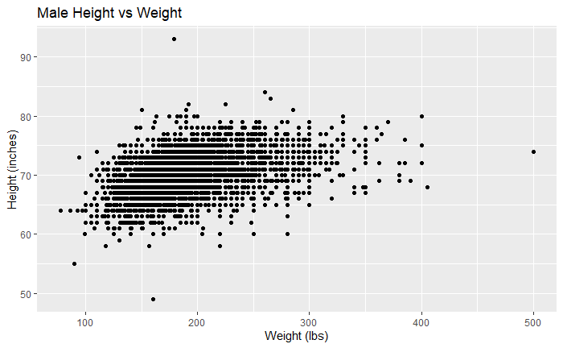

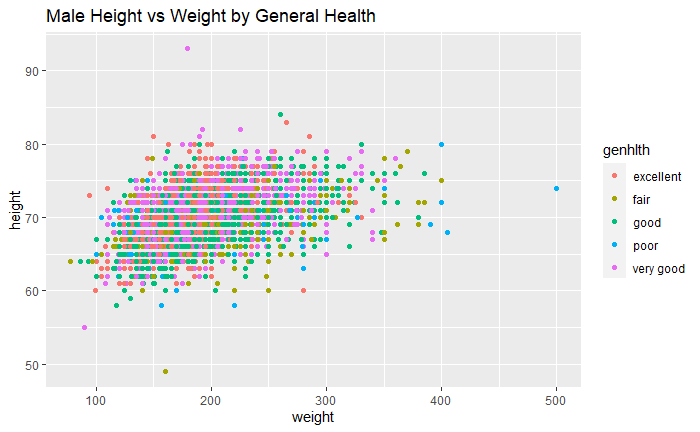

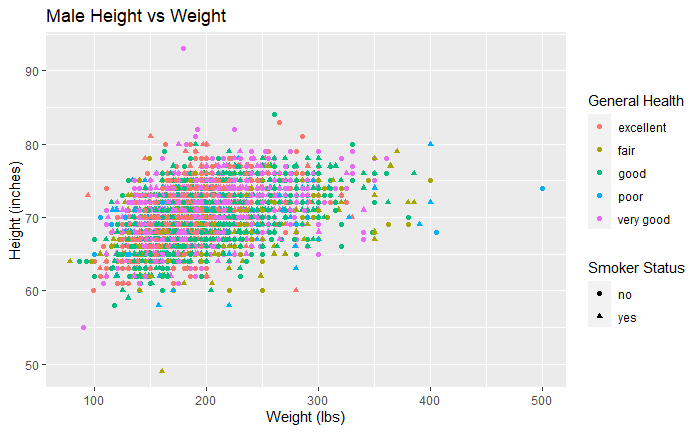

# Exercise 3: Working with categorical variables - facets

# Exercise 3: Working with categorical variables – facets

##1. Create a scatterplot for male heights and weights for people of each state (level) of general health.

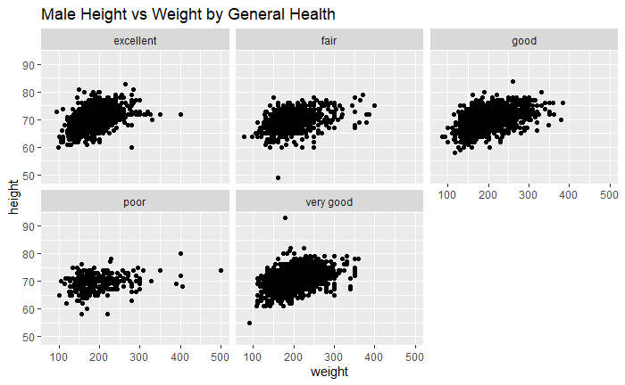

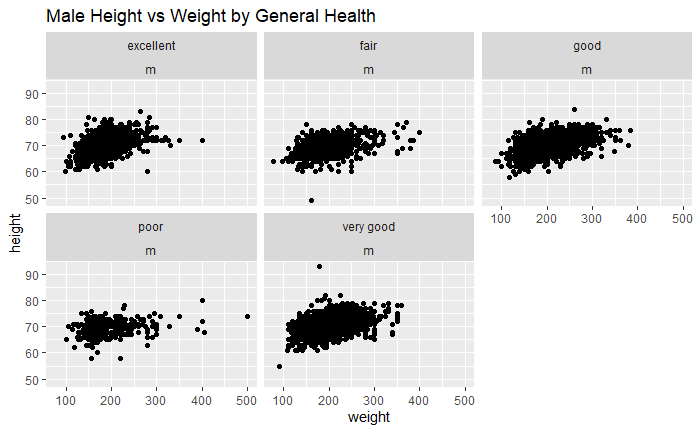

#🧪 Exercise 4: Line plots ## 1. Create a line plot for male heights and weights.

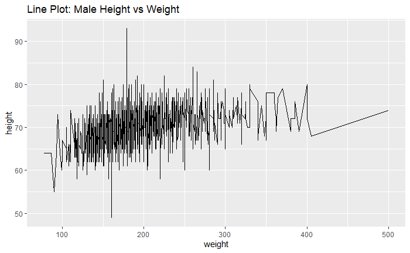

# 2. Create line plots for male heights and weights and female heights and weights on the same coordinate system.

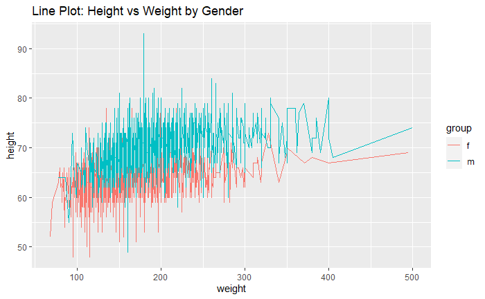

#Exercise 5: Bar plots ##1. Create a bar plot showing the number of people of each state (level) of general health (both men and women).

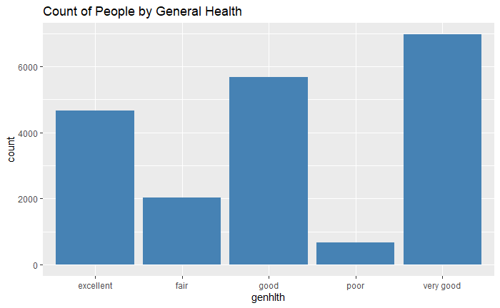

#2. Create a bar plot showing the number of people of each state of general health as a percentage split between men and women.

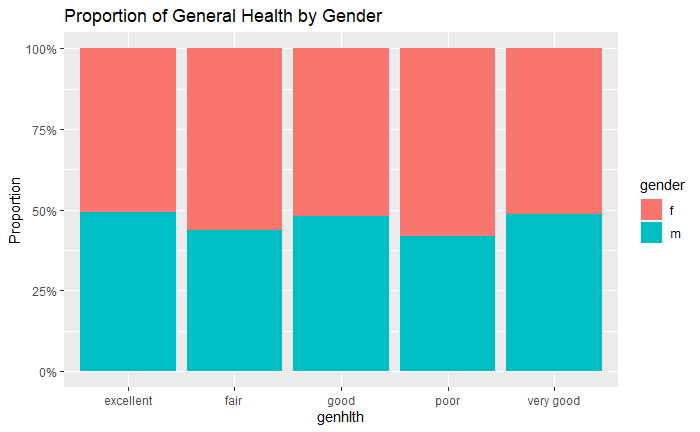